# DVD Rental Data Analysis

Ayan Dey

2024-01-01

**It is recommended, Before watching this document, Go through readme file for depth understanding** [click here to open README](https://github.com/ayandey1359/dvd-rental-da/blob/main/README.md)

## Let’s Start

```r
# importing libraries
library(odbc)
library(DBI)
library(tidyverse)
library(visdat)
```

```r
# building connection with database
con <- dbConnect(odbc::odbc(),
                 driver = "PostgreSQL Unicode",
                 server = "localhost",
                 port = 5432,
                 database = "my_db",
                 uid = "**********",
                 pwd = "*********")
```

## 1st business problem

*Customer Retention and Satisfaction:*  
- What strategies can be implemented to enhance customer satisfaction and encourage repeat rentals?  
> To solve this problem i need to retrieve customer,rental,inventory,and payment,film tables  
let see the ERD in LibreOffice Base

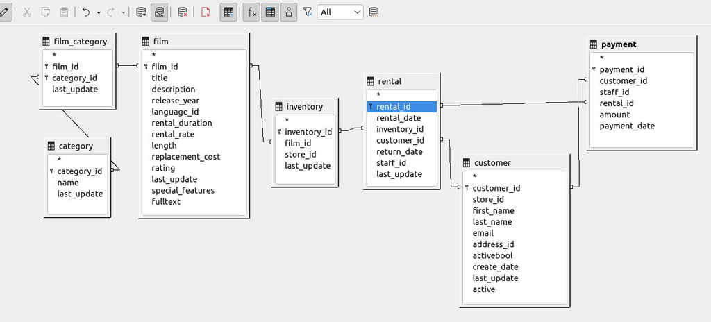

**The rental_id is a unique variable:** A film can stored in multiple DVD, a customer can take rent  
multiple DVD,But the rental_id is a id which only generated by each rental transaction .

```r
query <- "SELECT rental.rental_id,customer.customer_id, category.name,film.length,  film.rental_duration, film.rental_rate, payment.amount, film.rating, film.replacement_cost, customer.active FROM public.film_category film_category, public.film film, public.category category, public.inventory inventory, public.payment payment, public.customer customer, public.rental rental WHERE film_category.film_id = film.film_id AND film_category.category_id = category.category_id AND inventory.film_id = film.film_id AND payment.customer_id = customer.customer_id AND payment.rental_id = rental.rental_id AND rental.customer_id = customer.customer_id AND rental.inventory_id = inventory.inventory_id"
result1 <- dbGetQuery(con, query)
head(result1)
```

```
##   rental_id customer_id        name length rental_duration rental_rate amount
## 1      1520         341      Horror    153               6        4.99   7.99
## 2      1778         341 Documentary    130               5        0.99   1.99
## 3      1849         341         New    138               3        4.99   7.99
## 4      2829         341    Classics    100               5        2.99   2.99
## 5      3130         341       Games    165               6        4.99   7.99
## 6      3382         341      Sci-Fi     86               3        0.99   5.99
##   rating replacement_cost active
## 1      R            19.99      1
## 2     PG            15.99      1
## 3     PG             9.99      1
## 4      G            11.99      1
## 5      R            16.99      1
## 6      G            15.99      1
```

```r
# View(result1)
```

**Focused on Customer Retention and Satisfaction**

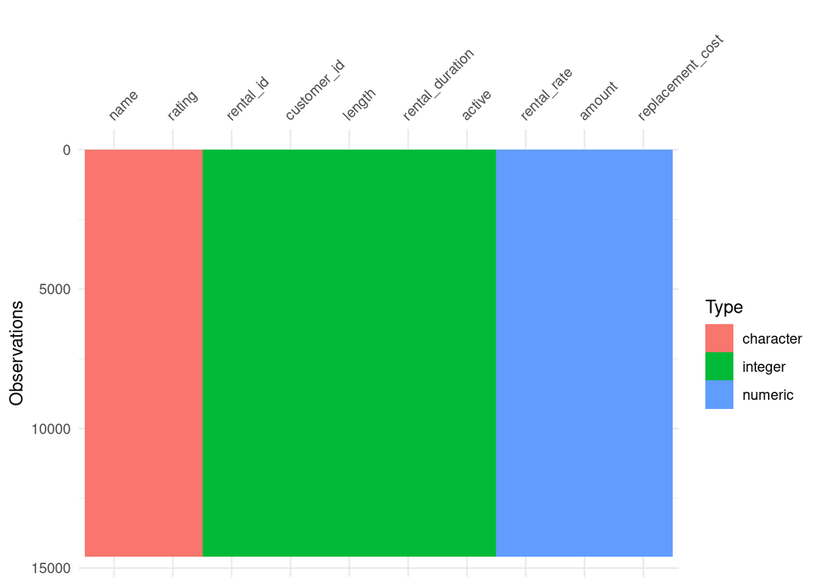

```r
# overview the data by heat map to identify the missing values
vis_dat(result1)
```

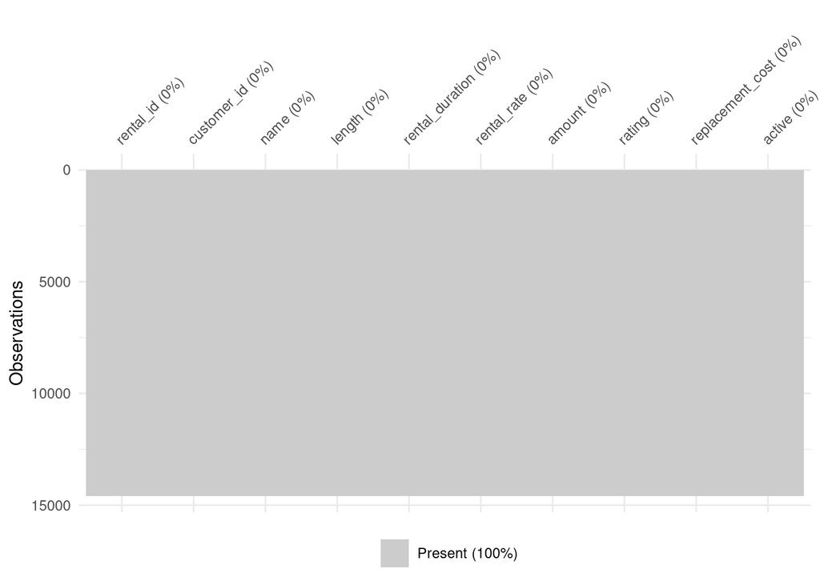

```r
# let focused on the missing values by heat map
vis_miss(result1)
```

- Missing Data Conclusion: This data don’t have missing values  
**duplicates**

```r
# Total number of rows
nrow(result1)
```

```
## [1] 14592
```

```r
# Number of rows have duplicate values
nrow(result1[duplicated(result1$rental_id), ])
```

```
## [1] 0
```

```r
# Removing duplicated values
result1 <- result1[!duplicated(result1$rental_id), ]
```

```r
# Number of rows of cleaned extracted data
nrow(result1)
```

```
## [1] 14592
```

```r
# View(result1)
```

At this point the current problem’s data is cleaned with no missing values at the primary column  
and no duplicate values are there  
## Data Manipulation

```r
# Lets see the Data-Type
glimpse(result1)
```

```
## Rows: 14,592
## Columns: 10
## $ rental_id        <int> 1520, 1778, 1849, 2829, 3130, 3382, 2190, 2914, 3081,…
## $ customer_id      <int> 341, 341, 341, 341, 341, 341, 342, 342, 342, 343, 343…
## $ name             <chr> "Horror", "Documentary", "New", "Classics", "Games", …
## $ length           <int> 153, 130, 138, 100, 165, 86, 161, 85, 119, 92, 82, 11…
## $ rental_duration  <int> 6, 5, 3, 5, 6, 3, 7, 4, 4, 7, 4, 5, 4, 6, 3, 7, 3, 5,…
## $ rental_rate      <dbl> 4.99, 0.99, 4.99, 2.99, 4.99, 0.99, 4.99, 4.99, 2.99,…
## $ amount           <dbl> 7.99, 1.99, 7.99, 2.99, 7.99, 5.99, 5.99, 5.99, 2.99,…
## $ rating           <chr> "R", "PG", "PG", "G", "R", "G", "R", "PG", "PG-13", "…
## $ replacement_cost <dbl> 19.99, 15.99, 9.99, 11.99, 16.99, 15.99, 22.99, 24.99…
## $ active           <int> 1, 1, 1, 1, 1, 1, 1, 1, 1, 1, 1, 1, 1, 1, 1, 1, 1, 1,…
```

```r
# rental_id column must be a character data type
result1$rental_id <- as.character(result1$rental_id)
class(result1$rental_id)
```

```
## [1] "character"
```

```r
# customer_id column must be a character data type
result1$customer_id <- as.character(result1$customer_id)
class(result1$customer_id)
```

```
## [1] "character"
```

```r
# Active status must be a logical
# But I keep it as numeric, it may help in later process
```

```r
# let's see data type
str(result1)
```

```
## 'data.frame':    14592 obs. of  10 variables:
##  $ rental_id       : chr  "1520" "1778" "1849" "2829" ...
##  $ customer_id     : chr  "341" "341" "341" "341" ...
##  $ name            : chr  "Horror" "Documentary" "New" "Classics" ...
##  $ length          : int  153 130 138 100 165 86 161 85 119 92 ...
##  $ rental_duration : int  6 5 3 5 6 3 7 4 4 7 ...
##  $ rental_rate     : num  4.99 0.99 4.99 2.99 4.99 0.99 4.99 4.99 2.99 4.99 ...
##  $ amount          : num  7.99 1.99 7.99 2.99 7.99 5.99 5.99 5.99 2.99 4.99 ...
##  $ rating          : chr  "R" "PG" "PG" "G" ...
##  $ replacement_cost: num  19.99 15.99 9.99 11.99 16.99 ...
##  $ active          : int  1 1 1 1 1 1 1 1 1 1 ...
```

```r
# observe rating column
result1 %>% drop_na(rating) %>% group_by(rating) %>% summarise(frequency=n())
```

```
## # A tibble: 5 × 2
##   rating frequency
##   <chr>      <int>
## 1 G           2508
## 2 NC-17       3004
## 3 PG          2938
## 4 PG-13       3245
## 5 R           2897
```

```r
# rating column must be a factor data type
result1$rating <- as.factor(result1$rating)
class(result1$rating)
```

```
## [1] "factor"
```

### Mathematical Operations

```r
# Data Statistics
summary(result1)
```

```
##   rental_id         customer_id            name               length
##  Length:14592       Length:14592       Length:14592       Min.   : 46.0
##  Class :character   Class :character   Class :character   1st Qu.: 81.0
##  Mode  :character   Mode  :character   Mode  :character   Median :113.0
##                                                           Mean   :114.9
##                                                           3rd Qu.:148.0
##                                                           Max.   :185.0
##  rental_duration  rental_rate        amount         rating     replacement_cost
##  Min.   :3.000   Min.   :0.990   Min.   : 0.000   G    :2508   Min.   : 9.99
##  1st Qu.:4.000   1st Qu.:0.990   1st Qu.: 2.990   NC-17:3004   1st Qu.:14.99
##  Median :5.000   Median :2.990   Median : 3.990   PG   :2938   Median :20.99
##  Mean   :4.936   Mean   :2.941   Mean   : 4.201   PG-13:3245   Mean   :20.20
##  3rd Qu.:6.000   3rd Qu.:4.990   3rd Qu.: 4.990   R    :2897   3rd Qu.:24.99
##  Max.   :7.000   Max.   :4.990   Max.   :11.990                Max.   :29.99
##      active
##  Min.   :0.0000
##  1st Qu.:1.0000
##  Median :1.0000
##  Mean   :0.9748
##  3rd Qu.:1.0000
##  Max.   :1.0000
```

deep dive into: result$length

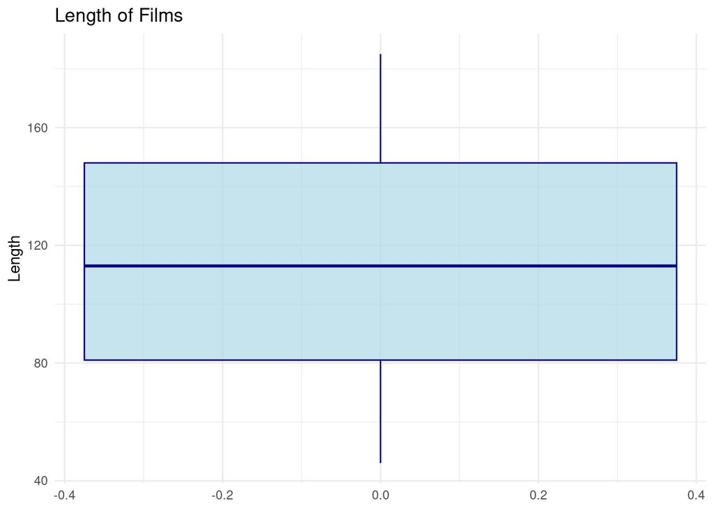

```r
# observe outliers in length column
# Create a box plot
ggplot(result1) +
  geom_boxplot(mapping =aes(y = result1$length),fill = "lightblue", color = "darkblue", alpha =     0.7)+
  ggtitle("Length of Films") +
   ylab("Length")+
    theme_minimal()
```

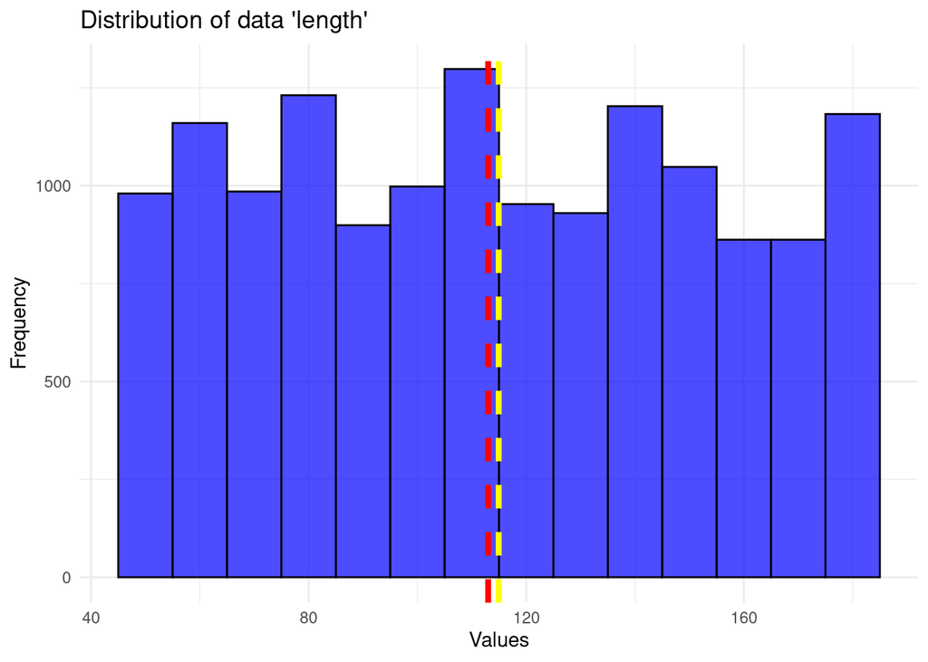

[output not shown]

```r
# observe the distribution of data in length column
ggplot(result1) +
  geom_histogram(mapping=aes(x=result1$length),binwidth = 10, fill = "blue", color = "black", alpha = 0.7) +
    geom_vline(xintercept = median(result1$length), linetype = "dashed", color = "red", size = 1.5)+
    geom_vline(xintercept = mean(result1$length), linetype = "dashed", color = "yellow", size = 1.5) +
  ggtitle("Distribution of data 'length'") +
  xlab("Values") +
  ylab("Frequency") +
  theme_minimal()
```

deep dive into: result$rental_duration

```r
summary(result1$rental_duration)
```

```
##    Min. 1st Qu.  Median    Mean 3rd Qu.    Max.
##   3.000   4.000   5.000   4.936   6.000   7.000
```

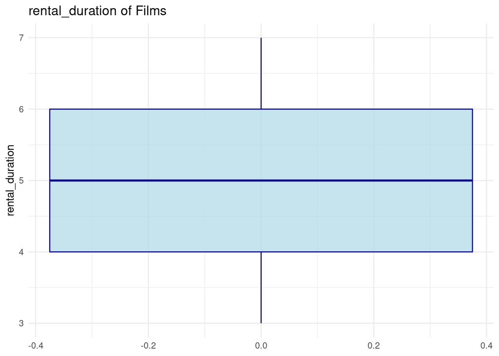

```r
# observe outliers in rental_duration column
# Create a box plot
ggplot(result1) +
  geom_boxplot(mapping =aes(y = rental_duration),fill = "lightblue", color = "darkblue", alpha =     0.7)+
  ggtitle("rental_duration of Films") +
   ylab("rental_duration")+
    theme_minimal()
```

```r
summary(result1$rental_duration)
```

```
##    Min. 1st Qu.  Median    Mean 3rd Qu.    Max.
##   3.000   4.000   5.000   4.936   6.000   7.000
```

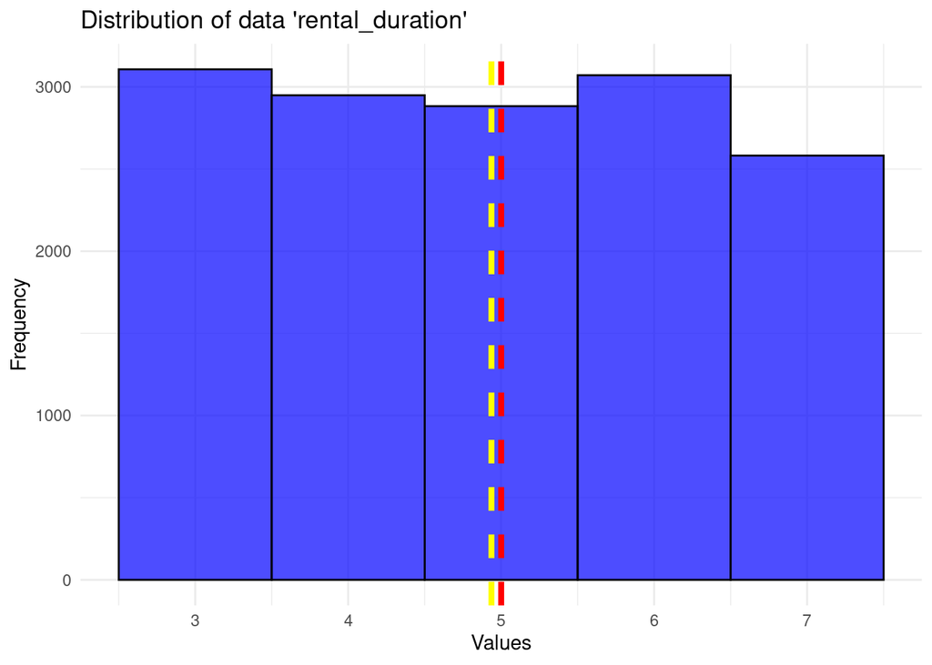

```
The Average rental duration of each DVD is 5 days, taking brandwidth= 1 day\
this data is uniformly distributed
```

```r
# observe the distribution of data in rental_duration column
ggplot(result1) +
  geom_histogram(mapping=aes(x=rental_duration),binwidth = 1, fill = "blue", color = "black", alpha = 0.7) +
    geom_vline(xintercept = median(result1$rental_duration), linetype = "dashed", color = "red", size = 1.5)+
    geom_vline(xintercept = mean(result1$rental_duration), linetype = "dashed", color = "yellow", size = 1.5) +
  ggtitle("Distribution of data 'rental_duration'") +
  xlab("Values") +
  ylab("Frequency") +
  theme_minimal()
```

```r
#
```

# **This Project is ‘Under Construction’**

```r
dbDisconnect(con)
```